# 📖 SAGEMATH NOTEBOOK

## (Phần 2. Ứng dụng trong các học phần Toán đại cương - biên soạn theo đề cương các môn học)

## 💡 Thông tin tài liệu

- Tài liệu được đính kèm theo **Đồ án 1**, đề tài: **"Hướng dẫn sử dụng phần mềm SageMath và ứng dụng trong các học phần Toán đại cương"**

  (Link toàn văn Đồ án: SageMath-Tutorial.
- Thực hiện bởi: **Nguyễn Trung Kiên** (20227180, Khoa Toán - Tin, Đại học Bách Khoa Hà Nội)
- Giảng viên hướng dẫn: **TS. Lê Văn Tứ**

Mọi ý kiến đóng góp, thắc mắc hoặc phản hồi, vui lòng gửi về trang cá nhân (Facebook): [Nguyễn Trung Kiên](https://www.facebook.com/kiennt.ethan/) và hòm thư điện tử: kiennt.ethan@gmail.com để được hỗ trợ sớm nhất.

Xin chân thành cảm ơn!

## 🛠️ Hướng dẫn sử dụng Notebook

1. Cài SageMath và Jupyter Notebook, hoặc truy cập trực tuyến:
   - [Trang chủ SageCell của SageMath](https://sagecell.sagemath.org) (đơn giản, không cần cài đặt)
   - [Trang chủ Cocalc](https://cocalc.com) (có thể mở file `.ipynb` trực tuyến)
2. Mở file `SageMath_Tutorial.ipynb` bằng Jupyter Notebook hoặc upload lên CoCalc.
3. Nhấn `Shift + Enter` tại mỗi ô để chạy lệnh SageMath.

Một số ô cần vài giây để xử lý, đặc biệt là các ô có biểu đồ.

```python
# Kiem tra SageMath da duoc cai dat
version()
```

```
'SageMath version 10.5, Release Date: 2024-12-04'
```

## Ứng dụng trong Giải tích 1

### Các câu lệnh cơ bản thường dùng

- `var('x')`: Khai báo biến.
- `solve(...)`: Giải phương trình hoặc bất phương trình.
- `limit(...)`: Tính giới hạn.
- `diff(...)`: Tính đạo hàm.
- `integrate(...)`: Tính tích phân.
- `plot(...)`, `plot3d(...)`: Vẽ đồ thị 2D, 3D.

### 1. Phép tính vi phân hàm một biến số

#### Tìm tập xác định của hàm số

Hàm: $y = \sqrt{2\ln{x} - 3}$

```python
var('x')
solve(log(x) >= 3/2, x)
```

```
[[2*log(x) - 3 == 0], [2*log(x) - 3 > 0]]
```

#### Tìm miền giá trị

Hàm: $y = \sqrt{1 - \left( \frac{x - 1}{x + 1} \right)^2}$ trên $(0;2)$

```python
var('x')
f(x) = sqrt(1 - ((x - 1)/(x + 1))^2)
f.find_local_maximum(0, 2), f.find_local_minimum(0, 2)
```

```
((1.0, 0.9999999994817399), (0.0001869787205816002, 8.740260678362169e-09))
```

#### Hàm hyperbolic

Hàm: $f(x) = \sinh(x) + \cosh(x)$

```python
f(x) = sinh(x) + cosh(x)
float(f(1))
```

```
2.718281828459045
```

#### Tìm hàm f(x)

Biết: $f(x + \frac{1}{x}) = x^2 + \frac{1}{x^2}$

```python
var('x t')
t = x + 1/x
expr = x^2 + 1/x^2
simplify(t^2 - 2)
```

```
(x + 1/x)^2 - 2
```

#### Tìm hàm ngược

Hàm: $y = \frac{1}{2}(e^x - e^{-x})$

```python
var('x y')
solve(y == (1/2)*(exp(x) - exp(-x)), x)
```

```
[x == log(y - sqrt(y^2 + 1)), x == log(y + sqrt(y^2 + 1))]
```

#### Tính giới hạn, liên tục

Hàm: $f(x) = \frac{x}{4 - x^2}$

```python
limit(x/(4 - x^2), x=1), limit(x/(4 - x^2), x=-1)
```

```
(1/3, -1/3)
```

#### Tính đạo hàm, cực trị, tiệm cận

Hàm: $y = x - \ln(1 + x)$

```python
f(x) = x - log(1 + x)
diff(f, x), diff(f, x, 2)
solve(diff(f, x) == 0, x)
limit(f, x=-oo), limit(f, x=+oo), limit(f, x=-1)
```

```
(x |--> -Infinity, x |--> +Infinity, x |--> Infinity)
```

### 2. Phép tính tích phân hàm một biến

#### Tích phân bất định

```python
integrate(tan(x)^3, x)
```

```
-1/2/(sin(x)^2 - 1) + 1/2*log(sin(x)^2 - 1)
```

#### Tích phân xác định

```python
integrate(exp(-x^2), (x, -1, 1))
```

```
sqrt(pi)*erf(1)
```

#### Tích phân suy rộng

```python
integrate(1/x^2, (x, 1, oo))
```

```
1
```

#### Diện tích hình phẳng

Giữa $y = \sin{x}$ và trục hoành trên $[0, \pi]$

```python
integrate(abs(sin(x)), (x, 0, pi))
```

```
2
```

#### Thể tích vật thể quay

Quay $y = \sqrt{x}$ quanh trục hoành trên $[0,1]$

```python
integrate(pi * (sqrt(x))^2, (x, 0, 1))
```

```
1/2*pi
```

### 3. Hàm số nhiều biến

#### Đạo hàm riêng và vi phân toàn phần

Hàm: $f(x, y) = \frac{x^2 y}{x^2 + y^2}$

```python
var('x y')
f(x, y) = (x^2 * y)/(x^2 + y^2)
diff(f, x), diff(f, y)
```

```
((x, y) |--> -2*x^3*y/(x^2 + y^2)^2 + 2*x*y/(x^2 + y^2),
 (x, y) |--> -2*x^2*y^2/(x^2 + y^2)^2 + x^2/(x^2 + y^2))
```

#### Khai triển chuỗi Taylor

Hàm: $f(x, y) = e^{x + y}$, khai triển theo $ x $

```python
var('x y')
f(x, y) = exp(x + y)
taylor(f, (x, 0), 3)
```

```
(x, y) |--> 1/6*x^3*e^y + 1/2*x^2*e^y + x*e^y + e^y
```

#### Đồ thị hàm nhiều biến

Hàm: $f(x,y) = \sin(x^2 + y^2) $

```python
var('x y')
plot3d(sin(x^2 + y^2), (x, -2, 2), (y, -2, 2))
```

[interactive chart not shown]

## Ứng dụng trong Giải tích 2

### Các câu lệnh thường dùng

- `integrate(...)`: Tính tích phân một, hai, ba lớp.
- `region_plot(...)`, `plot3d(...)`: Vẽ miền tích phân.
- `var('x y z')`: Khai báo biến.
- `diff(...)`: Đạo hàm riêng, gradient.

### Tích phân bội

#### Tích phân kép

Tính: $ \iint_D (x + y) \, dx\, dy, \quad D: 0 \le x \le 1, 0 \le y \le x $

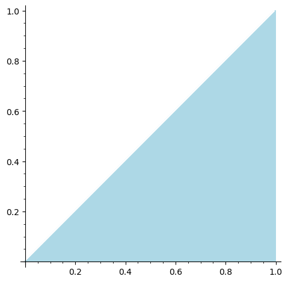

```python
var('x y')
integrate(integrate(x + y, y, 0, x), x, 0, 1)
region_plot(lambda x, y: y <= x and y >= 0 and x <= 1, (x, 0, 1), (y, 0, 1), incol='lightblue').show()
```

#### Tọa độ cực

Tính: $ \iint_D (x^2 + y^2) \, dx dy \quad D: x^2 + y^2 \le 1 $

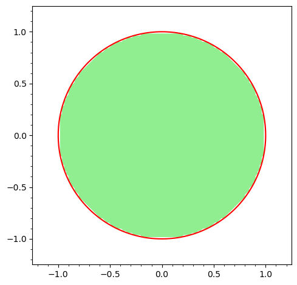

```python
var('r theta')
assume(r >= 0)
integrate(integrate(r^3, r, 0, 1), theta, 0, 2*pi)

# Vẽ miền hình tròn
var('x y')
circle = implicit_plot(x^2 + y^2 == 1, (x, -1.2, 1.2), (y, -1.2, 1.2), color='red')
region = region_plot(lambda x, y: x^2 + y^2 <= 1, (x, -1, 1), (y, -1, 1), incol='lightgreen')
show(region + circle)
```

#### Tích phân bội ba

Miền: $ E = \{(x, y, z): 0 \le x \le 1, 0 \le y \le 1 - x, 0 \le z \le x + y\} $

```python
var('x y z')
integrate(integrate(integrate(z, z, 0, x + y), y, 0, 1 - x), x, 0, 1)
```

```
1/8
```

### Ứng dụng tích phân bội

#### Tính diện tích mặt phẳng

Miền: $ D = \{(x, y): 0 \le x \le 1, \ 0 \le y \le \sqrt{1 - x^2}\} $

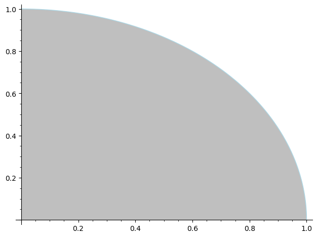

```python
var('x')
integrate(integrate(1, y, 0, sqrt(1 - x^2)), x, 0, 1)

# Vẽ miền
f(x) = sqrt(1 - x^2)
plot(f(x), (x, 0, 1), fill=True, color='lightblue').show()
```

#### Tính thể tích vật thể

Miền bị giới hạn bởi: $ z = x^2 + y^2 \text{ và } z = 4 $

```python
var('r theta')
assume(r >= 0)
integrate(integrate((4 - r^2) * r, r, 0, 2), theta, 0, 2*pi)
```

```
8*pi
```

#### Tích phân phụ thuộc tham số

Hàm: $I(a) = \int_0^1 \frac{x^a - 1}{\ln x} dx $

```python
var('a x')
assume(a > 0)
integrate((x^a - 1)/log(x), x, 0, 1)
```

[output not shown]

```
I*pi + log(a + 1)
```

### Tích phân đường

#### Loại 1: $ \int_C f(x,y) \, ds $, với $ y = x^2, 0 \le x \le 1 $

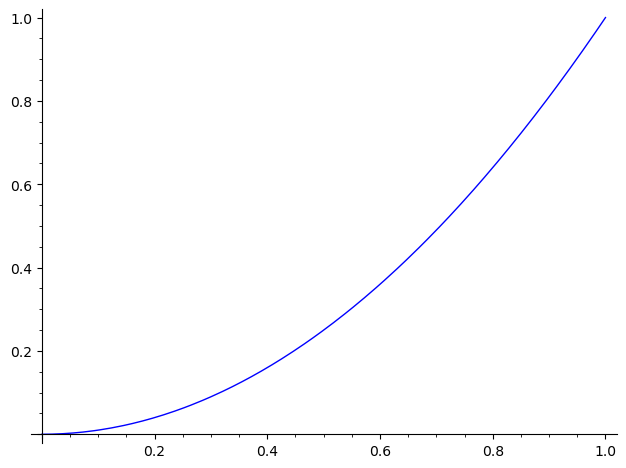

```python
f(x, y) = x + y
dx = 1
dy = diff(x^2, x)
ds = sqrt(dx^2 + dy^2)
integrate(f(x, x^2) * ds, x, 0, 1)

# Vẽ đường cong
var('x')
f(x) = x^2
plot(f(x), (x, 0, 1), color='blue').show()
```

#### Loại 2: $ \int_C x\,dx + y\,dy $, với $ C $ là đường tròn đơn vị

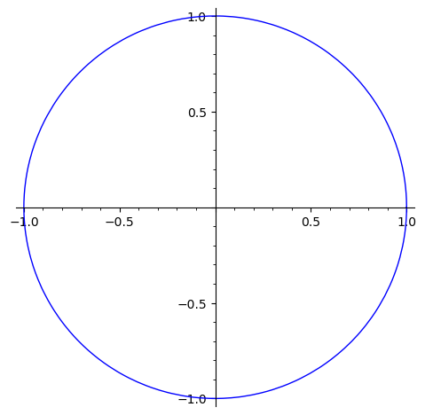

```python
var('t')
x(t) = cos(t)
y(t) = sin(t)
dx = diff(x(t), t)
dy = diff(y(t), t)
integrand = x(t)*dx + y(t)*dy
integrate(integrand, t, 0, 2*pi)

# Vẽ đường tròn
parametric_plot((x(t), y(t)), (t, 0, 2*pi), color='blue').show()
```

### Tích phân mặt

Hàm $ f(x,y,z) = z$ trên mặt $ z = 1 - x - y, \ x + y \le 1 $

```python
var('x y')
z(x, y) = 1 - x - y
f(x, y) = z(x, y)
integrate(integrate(f(x, y), y, 0, 1 - x), x, 0, 1)
```

```
1/6
```

### Lý thuyết trường

#### Đạo hàm theo hướng

Hàm: $ f(x, y) = x^2 y $, tại A(1, 2), theo hướng $ \vec{v} = (3, 4) $

```python
f(x, y) = x^2 * y
u = vector([3, 4]).normalized()
grad_f = vector([diff(f(x, y), x), diff(f(x, y), y)])
point = vector([1, 2])
grad_at_A = grad_f.subs(x=point[0], y=point[1])
grad_at_A.dot_product(u)
```

```
16/5
```

#### Gradient

```python
var('x y')
f(x, y) = x^2 * y
vector([diff(f(x, y), x), diff(f(x, y), y)])
```

```
(2*x*y, x^2)
```

## Ứng dụng trong Giải tích 3

### Các câu lệnh thường dùng

- `sum(...)`: Tính tổng chuỗi.
- `taylor(...)`: Khai triển chuỗi Taylor.
- `desolve(...)`: Giải phương trình vi phân.
- `desolve_system(...)`: Giải hệ phương trình vi phân.
- `desolve_laplace(...)`: Giải PTVP bằng biến đổi Laplace.
- `plot(...)`: Vẽ đồ thị minh họa chuỗi Fourier.

### Chuỗi số

Xét sự hội tụ của chuỗi: $ \sum_{n=1}^{\infty} \frac{1}{n^p} \quad \text{với } p > 1 $

```python
var('n')
f = 1 / n^100
sum(f, n, 1, oo)
```

```
189196075638244250590454866138987443745405683066133872266771…*pi^100
```

### Chuỗi hàm

Tính tổng chuỗi: $ \sum_{n=0}^{\infty} \frac{x^n}{n!} $

```python
var('x n')
f = x^n / factorial(n)
sum(f, n, 0, oo)
```

```
e^x
```

### Chuỗi lũy thừa: Taylor – Maclaurin

Khai triển chuỗi Maclaurin của $\sin(x)$

```python
taylor(sin(x), x, 0, 7)
```

```
-1/5040*x^7 + 1/120*x^5 - 1/6*x^3 + x
```

### Chuỗi Fourier

Khai triển chuỗi Fourier của $ f(x) = x $ trên $ [-\pi, \pi] $

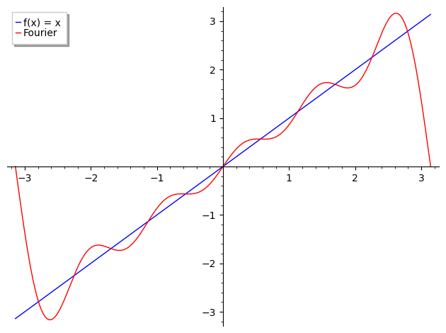

```python
var('x n')
f(x) = x
a0 = (1/pi) * integrate(f(x), x, -pi, pi)
an = (1/pi) * integrate(f(x) * cos(n*x), x, -pi, pi)
bn = (1/pi) * integrate(f(x) * sin(n*x), x, -pi, pi)
bn

# Ve do thi khai trien Fourier bac 5
fourier = sum(2*(-1)^(k+1)/k*sin(k*x) for k in (1..5))
p1 = plot(f(x), (x, -pi, pi), color='blue', legend_label='f(x) = x')
p2 = plot(fourier, (x, -pi, pi), color='red', legend_label='Fourier')
show(p1 + p2)
```

### Phương trình vi phân tuyến tính

Giải: $ y' + y = e^x $

```python
var('x y')
y = function('y')(x)
de = diff(y, x) + y == e^x
desolve(de, y)
```

```
1/2*(2*_C + e^(2*x))*e^(-x)
```

Giải: $ y'' - y = 0 $

```python
y = function('y')(x)
de2 = diff(y, x, 2) - y == 0
desolve(de2, y)
```

```
_K2*e^(-x) + _K1*e^x
```

### Phương trình Euler

Giải: $ x^2 y'' - x y' + y = 0 $

```python
y = function('y')(x)
de = x^2*diff(y, x, 2) - x*diff(y, x) + y == 0
desolve(de, y)
```

```
(_K2*log(x) + _K1)*x
```

### Hệ phương trình vi phân cấp 1

Giải: $ \begin{cases} x' = x + y \\ y' = x - y \end{cases} $

```python
t = var('t')
x = function('x')(t)
y = function('y')(t)
de1 = diff(x, t) == x + y
de2 = diff(y, t) == x - y
desolve_system([de1, de2], [x, y])
```

```
[x(t) == 1/2*sqrt(2)*(x(0) + y(0))*sinh(sqrt(2)*t) + cosh(sqrt(2)*t)*x(0),
 y(t) == 1/2*sqrt(2)*(x(0) - y(0))*sinh(sqrt(2)*t) + cosh(sqrt(2)*t)*y(0)]
```

### Biến đổi Laplace

Giải: $ y'' + y = \sin(t), \quad y(0) = 0, \ y'(0) = 1 $

```python
var('t s')
y = function('y')(t)
de = diff(y, t, 2) + y == sin(t)
desolve_laplace(de, y, ivar=t)
```

```
-1/2*t*cos(t) + 1/2*(2*D[0](y)(0) + 1)*sin(t) + cos(t)*y(0)
```

## Ứng dụng trong Đại số tuyến tính

### Các câu lệnh cơ bản

- `Matrix(...)`, `vector(...)`: Khởi tạo ma trận, vector.
- `.det()`, `.rank()`, `.inverse()`, `.eigenvalues()`: Các phép toán ma trận.
- `solve(...)`: Giải hệ phương trình.
- `Set(...)`: Làm việc với tập hợp.
- `.project_onto(...)`, `.normalized()`: Hình chiếu, chuẩn hóa vector.

### Phép toán Logic và Tập hợp

Ví dụ tính hợp và giao của hai tập hợp:

```python
A = Set([1, 2, 3])
B = Set([3, 4, 5])
A.union(B)          # Hợp
```

```
{1, 2, 3, 4, 5}
```

```python
A.intersection(B)   # Giao
```

```
{3}
```

### Ánh xạ, tìm ảnh và nghịch ảnh

Cho ánh xạ $ f(x) = x^2 $, tính ảnh của 3 và nghịch ảnh của 9.

```python
var('x')
f = x^2
f(x=3)
```

```
9
```

```python
f.inverse_function()(9)
```

[output not shown]

### Cấu trúc đại số: nhóm, vành, trường

Ví dụ về nhóm Abel:

```python
G = AbelianGroup(2)
G.gens()
```

```
(f0, f1)
```

### Số phức: module, liên hợp, nghiệm

Tính module, liên hợp và nghiệm phức:

```python
z = 3 + 4*I
abs(z)          # Module
conjugate(z)    # Liên hợp
solve(x^2 + 1 == 0, x)  # Nghiệm phức
```

```
[x == -I, x == I]
```

### Căn bậc n của số phức

Ví dụ tìm căn bậc ba của số phức:

```python
z = - I
z.nth_root(3)
```

```
I
```

### Ma trận và các phép toán cơ bản

Tính định thức, nghịch đảo, bình phương, hạng và giải hệ tuyến tính:

```python
A = Matrix([[1, 2], [3, 4]])
A.det()
```

```
-2
```

```python
A.inverse()
```

```
[  -2    1]
[ 3/2 -1/2]
```

```python
A^2
```

```
[ 7 10]
[15 22]
```

```python
A.rank()
```

```
2
```

```python
x = var('x1 x2')
solve(A * vector([x1, x2]) == vector([1, 2]), x1, x2)
```

[output not shown]

### Kiểm tra tính độc lập tuyến tính

Tính hạng của ma trận gồm các vector:

```python
v1 = vector([1, 2])
v2 = vector([2, 4])
matrix([v1, v2]).rank()
```

```
1
```

### Tìm cơ sở và số chiều không gian sinh

Tìm cơ sở và số chiều không gian cột:

```python
v1 = vector([1, 0])
v2 = vector([0, 1])
matrix([v1, v2]).column_space()
```

```
Free module of degree 2 and rank 2 over Integer Ring
Echelon basis matrix:
[1 0]
[0 1]
```

### Giá trị và vector riêng

Tính giá trị riêng và vector riêng của ma trận:

```python
A = Matrix([[1, 2], [3, 4]])
A.eigenvalues()
```

```
[-0.3722813232690144?, 5.372281323269015?]
```

```python
A.eigenvectors()
```

[output not shown]

### Chéo hóa ma trận

Thực hiện chéo hóa:

```python
A = Matrix([[4, 1], [2, 3]])
A.diagonalize()
```

[output not shown]

### Trực chuẩn hóa, chuyển cơ sở và hình chiếu

Chuẩn hóa vector và tính hình chiếu trực giao:

```python
v1 = vector([1, 2])
v2 = vector([3, 4])
v1.normalized()
v1.project_onto(v2)
```

[output not shown]

### Vẽ đường cong phẳng và mặt bậc hai

Vẽ đường cong và mặt bậc hai:

```python
# Đường cong 2D
var('x y')
plot(x^2 + y^2, (x, -2, 2), (y, -2, 2))
```

[output not shown]

## Ứng dụng trong Xác suất thống kê

### Tổ hợp, chỉnh hợp, giai thừa

Sử dụng các hàm `factorial`, `binomial` để tính giai thừa và tổ hợp. Tính chỉnh hợp bằng công thức.

```python
factorial(5)             # 5! = 120
```

```
120
```

```python
binomial(5, 3)           # Tổ hợp chập 3 của 5
```

```
10
```

```python
factorial(4)/factorial(2)  # Chỉnh hợp chập 2 của 4
```

```
12
```

### Biến ngẫu nhiên và phân phối xác suất

Tính kỳ vọng và phương sai của biến rời rạc.

```python
X = [1, 2, 3]
P = [0.2, 0.5, 0.3]
mean = sum(x * p for x, p in zip(X, P))
variance = sum((x - mean)^2 * p for x, p in zip(X, P))
(mean, variance)
```

```
(2.10000000000000, 0.490000000000000)
```

### Dùng NumPy hoặc SciPy để thống kê mô tả

```python
import numpy as np
data = [10, 20, 30, 40, 50]
np.mean(data), np.var(data), np.std(data)
```

```
(30.0, 200.0, 14.142135623730951)
```

```python
from scipy.stats import describe
describe(data).mean, describe(data).variance
```

```
(30.0, 250.0)
```

### Vẽ đồ thị phân phối nhị thức

Ví dụ với $n = 10, p = 0.5$

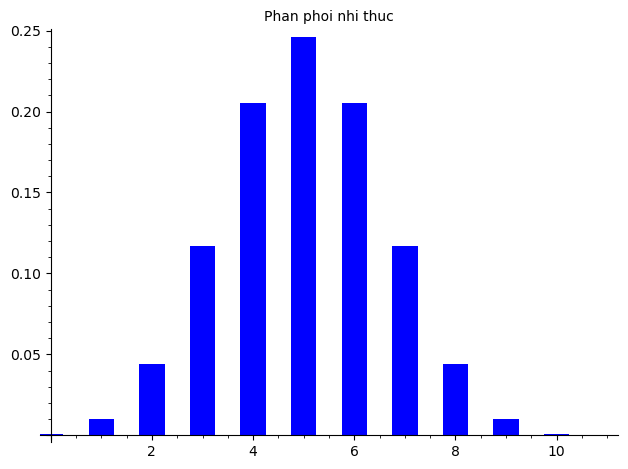

```python
var('k')
p = 0.5
n = 10
P = [binomial(n, k) * p^k * (1 - p)^(n - k) for k in range(n + 1)]
bar_chart(P, width=0.5, title='Phan phoi nhi thuc', axes=True)
```

### Biến ngẫu nhiên nhiều chiều

Tính phân phối xác suất biên:

```python
var('x y')
f = x * y
integrate(f, (x, 0, 1))  # Phân phối biên theo y
```

```
1/2*y
```

### Ước lượng tham số

Tính khoảng tin cậy 95% cho trung bình.

```python
var('x n s')
mu = x + 1.96 * s / sqrt(n)
mu.subs({x: 50, s: 10, n: 100})
```

```
51.9600000000000
```

### Kiểm định giả thuyết

Tính thống kê Z kiểm định trung bình.

```python
var('xbar mu sigma n')
Z = (xbar - mu) / (sigma / sqrt(n))
Z.subs({xbar: 110, mu: 100, sigma: 15, n: 30})
```

```
2/3*sqrt(30)
```

### Thống kê mô tả

Sử dụng SciPy để mô tả dữ liệu thống kê.

```python
from scipy.stats import describe
data = [10, 20, 30, 40, 50]
describe(data)
```

```
DescribeResult(nobs=5, minmax=(10, 50), mean=30.0, variance=250.0, skewness=0.0, kurtosis=-1.3)
```

### Phân tích hồi quy tuyến tính

Giải hệ phương trình để tìm hệ số hồi quy.

```python
var('x')
data = [(1, 2), (2, 4), (3, 6)]
m, b = var('m b')
model = m * x + b
eqs = [model.subs(x=xv) == yv for xv, yv in data]
solve(eqs, m, b)
```

```
[[m == 2, b == 0]]
```

### Phân tích phương sai (ANOVA)

Dùng SciPy để kiểm định sự khác biệt giữa hai nhóm.

```python
from scipy.stats import f_oneway
group1 = [23, 20, 25, 22]
group2 = [27, 29, 30, 28]
f_oneway(group1, group2)
```

```
F_onewayResult(statistic=24.0, pvalue=0.002713682035093796)
```